# Exploring the BRFSS 2013 data

## Setup

### Load packages

```r
library(tidyverse)
```

### Load data

Get data file if it doesn’t exist

```r
url <- "https://d18ky98rnyall9.cloudfront.net/_384b2d9eda4b29131fb681b243a7767d_brfss2013.RData"

 destfile <- "./brfss2013.RData"
  if (!file.exists(destfile)) {
    setInternet2(TRUE)
    download.file(url ,destfile,method="auto")
 }
 load(destfile)
```

## Part 1: Data

BRFSS conducts both landline telephone and cellular telephone based surveys. In conducting the BRFSS landline telephone survey, interviewers collect data from a randomly selected adult in a household. In conducting the cellular telephone version of the BRFSS questionnaire, interviewers collect data from an adult who participates by using a cellular telephone and resides in a private residence or college housing. The telephone numbers dialed are generated using random number generation.

Health characteristics estimated from the BRFSS pertain to the non-institutionalized adult population, aged 18 years or older, who reside in the US.

Using this methodology helps control selection bias. However the survey is somewhat lengthy (often around 45 minutes to complete), and additionally pertains to potentaially sensitive topics which may introduce non-response bias.

This is an observational study over a limited point in time.

## Part 2: Research questions

Sleep is a critical indicator of overall health and well-being. The exact sleep needs for individuals vary, however the National Sleep Foundation has provided the following sleep duration recommendations.<sup>1</sup>

- Younger adults (18-25): 7-9 hours
- Adults (26-64): 7-9 hours
- Older adults (65+): 7-8 hours

Using the BRFSS 2013 dataset we will examine potential relations between sleep duration and a variatey of health and social variables.

**Research quesion 1:** Is there a relationship between time slept and alcohol consumption?

**Research quesion 2:** Is there a relationship between time slept and number of children in the household?

**Research quesion 3:** Is there a relationship between time slept and the type of payment for work?

## Part 3: Exploratory data analysis

Create dataset with relavent variables

```r
brfss_clean <- brfss2013 %>%
        select(sleptim1, avedrnk2, children, scntlpad)
```

**Research quesion 1:**

```r
brfss_sl_alc <- brfss_clean %>%
        select(sleptim1, avedrnk2) %>%
        drop_na()

summary(brfss_sl_alc)
```

```
##     sleptim1         avedrnk2
##  Min.   : 1.000   Min.   : 1.000
##  1st Qu.: 6.000   1st Qu.: 1.000
##  Median : 7.000   Median : 2.000
##  Mean   : 7.038   Mean   : 2.209
##  3rd Qu.: 8.000   3rd Qu.: 2.000
##  Max.   :24.000   Max.   :76.000
```

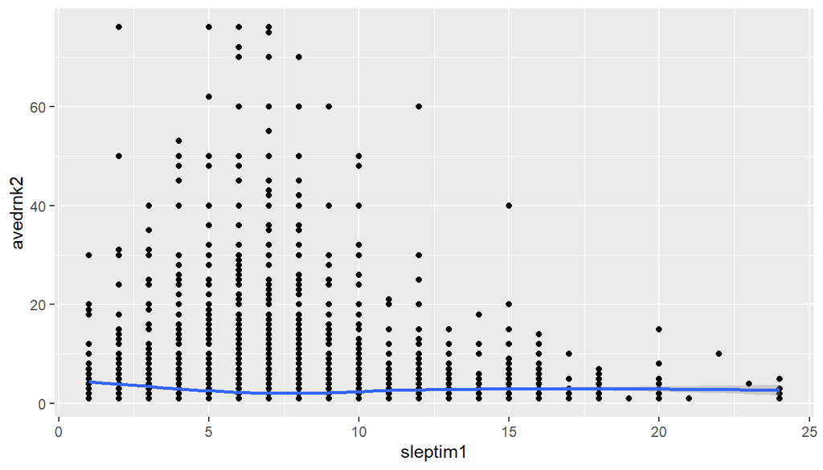

```r
p_alc <- ggplot(data = brfss_sl_alc, aes(x = sleptim1, y = avedrnk2))

p_alc + geom_point() + geom_smooth()
```

**Research quesion 2:**

```r
#prepare dataset, remove obvious outliers and na
brfss_sl_chl <- brfss2013 %>%
        select(sleptim1, children, X_ageg5yr) %>%
        drop_na() %>%
        filter(children < 20 & sleptim1 < 24)

#look at the data with tables and numerical summary
head(brfss_sl_chl)
```

```
##   sleptim1 children    X_ageg5yr
## 1        6        2 Age 50 to 54
## 2        9        0 Age 55 to 59
## 3        8        0 Age 60 to 64
## 4        6        0 Age 65 to 69
## 5        8        0 Age 45 to 49
## 6        7        1 Age 35 to 39
```

```r
summary(brfss_sl_chl)
```

```
##     sleptim1        children                 X_ageg5yr
##  Min.   : 1.00   Min.   : 0.0000   Age 60 to 64   : 52834
##  1st Qu.: 6.00   1st Qu.: 0.0000   Age 55 to 59   : 51736
##  Median : 7.00   Median : 0.0000   Age 65 to 69   : 49155
##  Mean   : 7.05   Mean   : 0.5218   Age 50 to 54   : 46441
##  3rd Qu.: 8.00   3rd Qu.: 1.0000   Age 70 to 74   : 39138
##  Max.   :23.00   Max.   :17.0000   Age 80 or older: 38821
##                                    (Other)        :200112
```

```r
brfss_sl_chl %>%
  group_by(X_ageg5yr) %>%
  summarise(mean = mean(children), median = median(children))
```

```
## # A tibble: 13 x 3
##    X_ageg5yr         mean median
##    <fct>            <dbl>  <dbl>
##  1 Age 18 to 24    0.626       0
##  2 Age 25 to 29    0.910       0
##  3 Age 30 to 34    1.52        1
##  4 Age 35 to 39    1.78        2
##  5 Age 40 to 44    1.47        1
##  6 Age 45 to 49    0.931       1
##  7 Age 50 to 54    0.439       0
##  8 Age 55 to 59    0.192       0
##  9 Age 60 to 64    0.106       0
## 10 Age 65 to 69    0.0709      0
## 11 Age 70 to 74    0.0503      0
## 12 Age 75 to 79    0.0350      0
## 13 Age 80 or older 0.0230      0
```

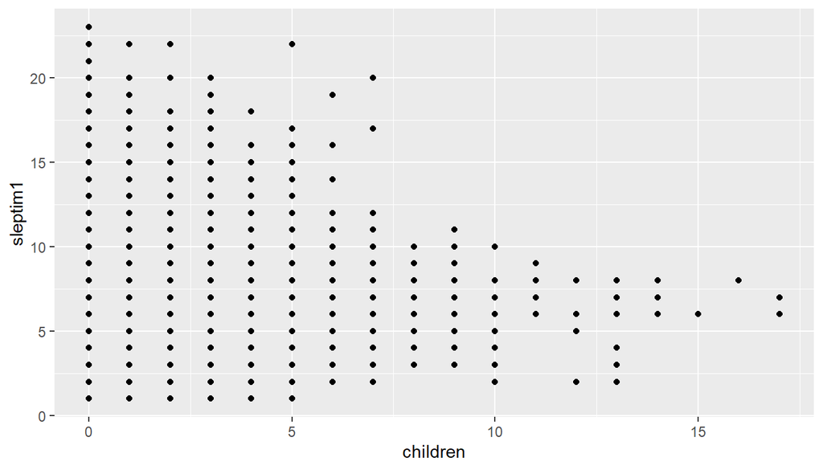

```r
#look at the data visually
p_chl <- ggplot(data = brfss_sl_chl, aes(x = children, y = sleptim1))

p_chl + geom_point()
```

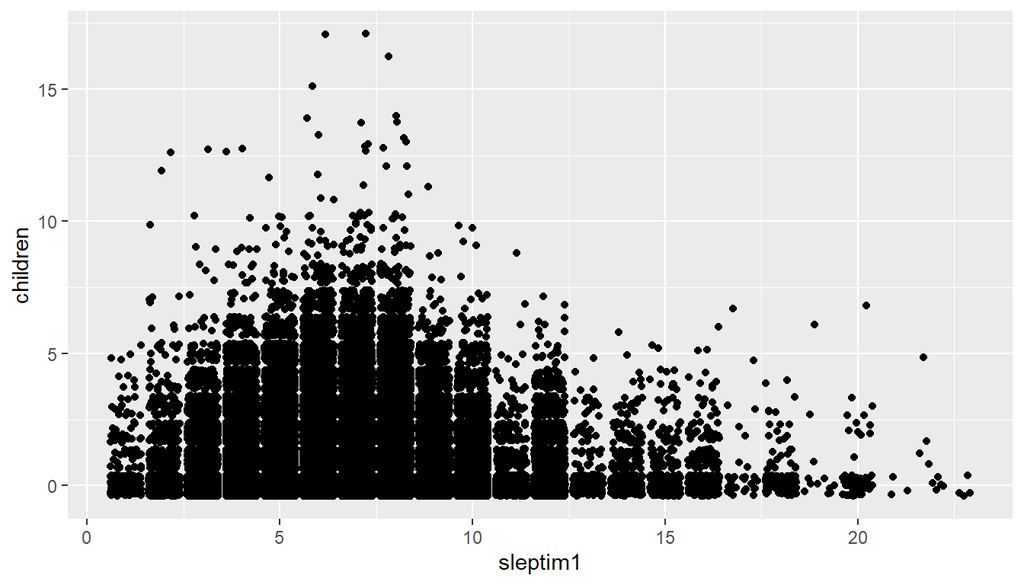

```r
p_chl + geom_jitter() + coord_flip()
```

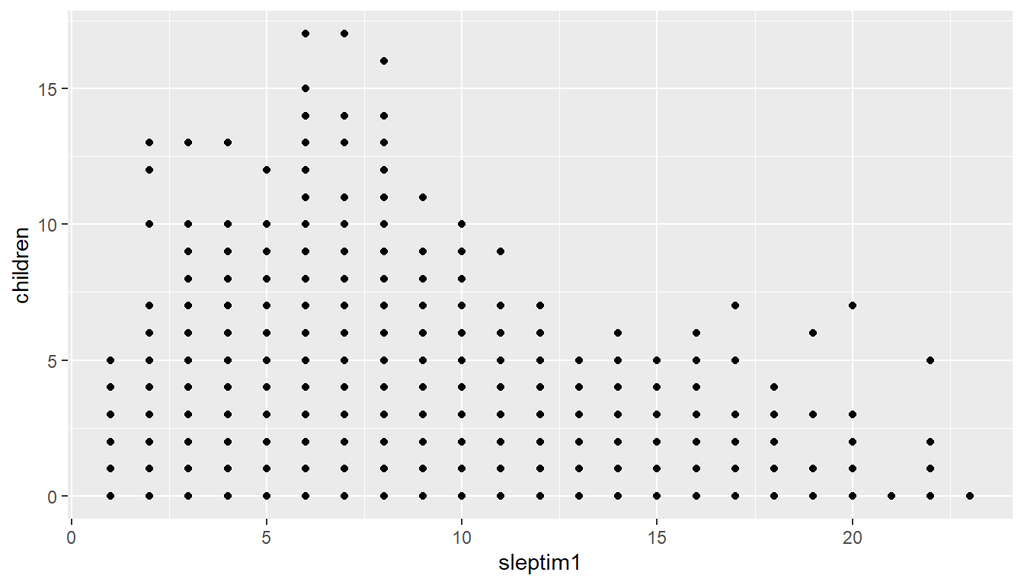

```r
ggplot(data = brfss_sl_chl, aes(x = sleptim1, y = children)) +
  geom_point()
```

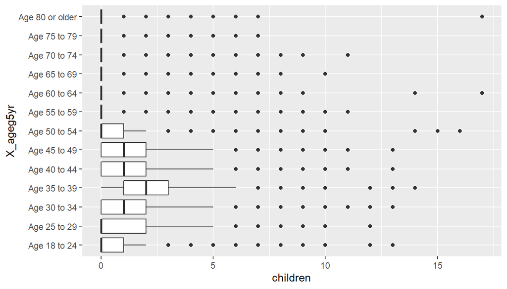

```r
ag_ch <- ggplot(data = brfss_sl_chl, aes(x = X_ageg5yr, y = children))

ag_ch + geom_boxplot() + coord_flip()
```

```r
a_c <- brfss_sl_chl %>%
  group_by(X_ageg5yr) %>%
  mutate(outlier_high = children > quantile(children, .75) + 1.50*IQR(children), outlier_low = children < quantile(children, .25) - 1.50*IQR(children)) %>%
  ungroup()

a_c <- a_c %>%
  group_by(X_ageg5yr) %>%
  mutate(outlier = children > median(children) + IQR(children) * 1.5) %>%
  ungroup()

a_c <- a_c %>%
  mutate(outlier_color = case_when(outlier_high ~ "red", outlier_low ~ "steelblue"))

head(a_c)
```

```
## # A tibble: 6 x 7
##   sleptim1 children X_ageg5yr outlier_high outlier_low outlier
##      <int>    <int> <fct>     <lgl>        <lgl>       <lgl>
## 1        6        2 Age 50 t~ FALSE        FALSE       TRUE
## 2        9        0 Age 55 t~ FALSE        FALSE       FALSE
## 3        8        0 Age 60 t~ FALSE        FALSE       FALSE
## 4        6        0 Age 65 t~ FALSE        FALSE       FALSE
## 5        8        0 Age 45 t~ FALSE        FALSE       FALSE
## 6        7        1 Age 35 t~ FALSE        FALSE       FALSE
## # ... with 1 more variable: outlier_color <chr>
```

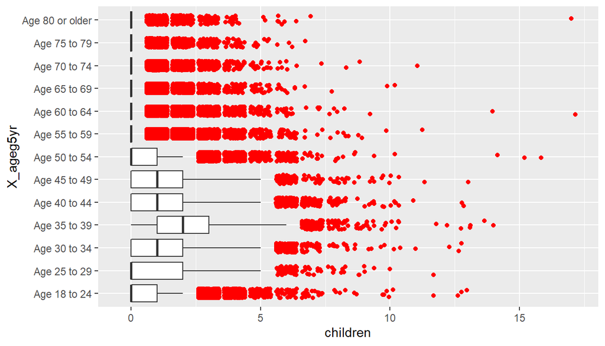

```r
ggplot(data = a_c, aes(x = X_ageg5yr, y = children)) +
         geom_boxplot(outlier.shape = NA) + coord_flip() + geom_jitter(color = a_c$outlier_color, width = .2)
```

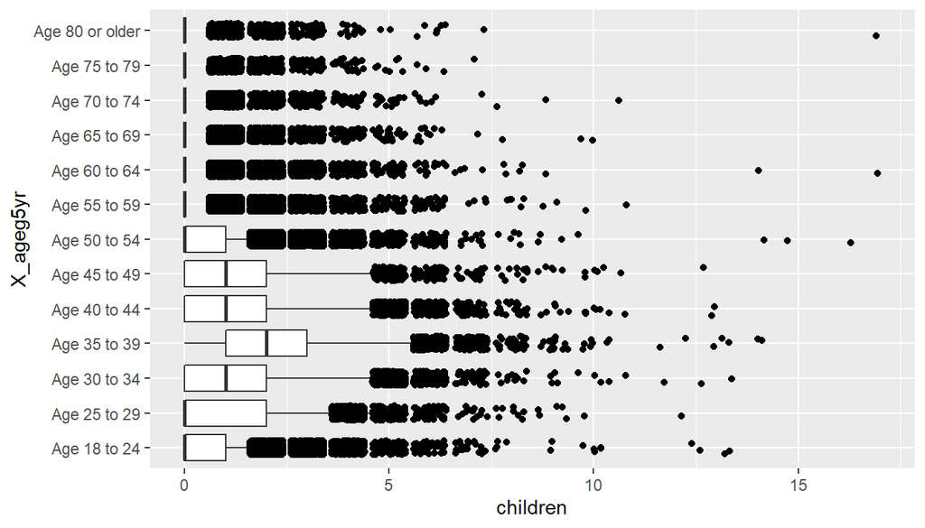

```r
ggplot(data = a_c, aes(x = X_ageg5yr, y = children)) +
         geom_boxplot(outlier.shape = NA) + coord_flip() +
          geom_jitter(data = filter(a_c, outlier ==T), width = .2)
```

**Research quesion 3:**

```r
brfss_sl_pay <- brfss_clean %>%
        select(sleptim1, scntlpad) %>%
        drop_na()

brfss_sl_pay %>%
  group_by(scntlpad) %>%
  summarise(median(sleptim1), mean(sleptim1), IQR(sleptim1))
```

```
## # A tibble: 4 x 4
##   scntlpad               `median(sleptim1~ `mean(sleptim1)` `IQR(sleptim1)`
##   <fct>                              <dbl>            <dbl>           <dbl>
## 1 Paid by salary                         7             7.36               1
## 2 Paid by the hour                       7             7.19               2
## 3 Paid by the job / task                 8             7.33               2
## 4 Paid some other way                    7             7.37               2
```

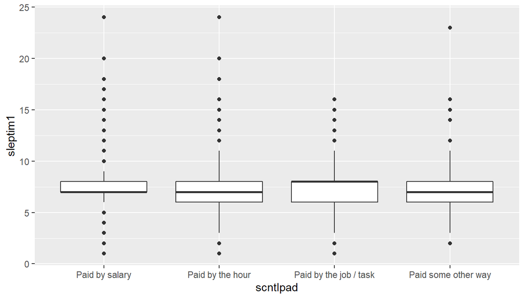

```r
p_pay <- ggplot(data = brfss_sl_pay, aes(x = scntlpad, y = sleptim1))

p_pay + geom_boxplot()
```

References: 1: National Sleep Foundation’s sleep time duration recommendations: methodology and results summary. Sleep Health. 2015 Mar;1(1):40-43. doi: 10.1016/j.sleh.2014.12.010. Epub 2015 Jan 8.